# Reproducible Research: Peer Assessment 1

## Loading and preprocessing the data

First, I need to make sure that you have the necessary packages installed on your computer.

```r
if (!require('ggplot2') | !require("RCurl") | !require("dplyr")){
  print('packages ggplot2, RCurl, and dplyr are required to run this code,
        Please install them on your computer and re-run the code')
  return
}
```

Then I check if you have the csv. If not, I check if you have the zip. If not, I download the zip. Once I am sure you have the zip, I unzip it. Once I am sure you have the .csv, I read it.

```r
cache_dir <- getwd()
zip_name <- paste0(cache_dir,'/','repdata-data-activity.zip')
csv_name <- paste0(cache_dir,'/','activity.csv')
fex <- file.exists(csv_name,zip_name)

if(!any(fex)){
  zip_url <- 'https://d396qusza40orc.cloudfront.net/repdata%2Fdata%2Factivity.zip'
  zip_bin <- getBinaryURL(zip_url,ssl.verifypeer = FALSE)
  zip_file <- file(zip_name,open="wb")
  writeBin(zip_bin,zip_file)
  close(zip_file)
  fex <- file.exists(csv_name,zip_name)
}
if (!fex[1]){
  unzip(zipfile = zip_name)
}
d <- read.csv(csv_name, na.string="NA", sep=",")
```

### Extracting the relevant data: step 1 & 2’s target dataset

First step is to clear the NA’s out of the dataset. This will actually remove several days from the analysis, assumedly before the subject had begun wearing the device. We first sort the data by date and by interval. All that is asked of us for the interval sorting is the mean.

```r
d_NA_strip = filter(d, !is.na(steps))

tot_stp_NA_strip = aggregate(d_NA_strip$steps,list(date = d_NA_strip$date),sum)
avg_stp_NA_strip = aggregate(d_NA_strip$steps, list(interval = d_NA_strip$interval), mean)

avg_tot_stp_day_strip_NA = mean(tot_stp_NA_strip$x)
md_tot_stp_day_strip_NA  = median(tot_stp_NA_strip$x)
```

## What is mean total number of steps taken per day?

The mean number of steps per day, and the median number of steps per day for the entire dataset, NA’s exluded, are:

```r
print(avg_tot_stp_day_strip_NA)
```

```
## [1] 10766.19
```

```r
print(md_tot_stp_day_strip_NA)
```

```
## [1] 10765
```

respectively, and the most active 5 minute interval is:

```r
max_int = (avg_stp_NA_strip$x == max(avg_stp_NA_strip$x))
max_int_hour = avg_stp_NA_strip$interval[max_int]%/%100
max_int_minute = avg_stp_NA_strip$interval[max_int]%%100
print(paste('Interval ',avg_stp_NA_strip$interval[max_int]/5,': ',
            'from ',max_int_hour,':',max_int_minute,' through ',
            max_int_hour,':',max_int_minute+5))
```

```
## [1] "Interval  167 :  from  8 : 35  through  8 : 40"
```

## What is the average daily activity pattern?

[figure not shown]

```r
hist(tot_stp_NA_strip$x,xlab = "Daily Activity (steps)",ylab = "Frequency",
     main = "Histogram of Steps",breaks = 10)
```

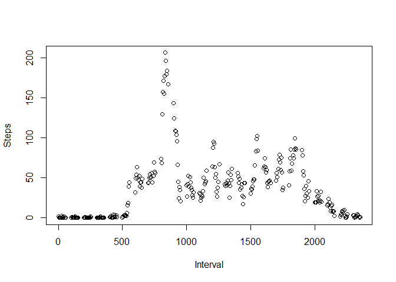

```r
plot(avg_stp_NA_strip$interval,avg_stp_NA_strip$x,xlab = 'Interval',ylab = 'Steps')
```

## Imputing missing values

Any days with ONLY NA values will be replaced with zero first, as averaging a zero length array will probably give problems.

```r
num_NA = length(d$steps)-length(d_NA_strip$steps)
FULL_NA_FILTER = !(d$date %in% d_NA_strip$date)
d$steps[FULL_NA_FILTER] = 0
```

The total number of NA’s (before filling in the blank days) is:

```r
print(num_NA)
```

```
## [1] 2304
```

I now replace the NAs with the average value/interval. I prefer for loops for complicated work, as I learned to code on a more general language, and practicing ‘apply’ won’t help in C, Python, or Java.

```r
NAs = is.na(d$steps)
for( st_na in seq_along(d$steps[NAs])){
  interv = d$interval[NAs][st_na]
  d$steps[NAs][st_na] = avg_stp_int_omit_NA$x[avg_stp_int_omit_NA$interval == interv]
}
```

```r
tot_stp_day = aggregate(d$steps, list(date = d$date), sum)
avg_tot_stp_day = mean(tot_stp_day$x)
md_tot_stp_day  = median(tot_stp_day$x)

avg_stp_int = aggregate(d$steps, list(interval = d$interval), mean)
```

The mean number of steps per day, and the median number of steps per day for the entire dataset, NA’s filled in, are:

```r
print(avg_tot_stp_day)
```

```
## [1] 9354.23
```

```r
print(md_tot_stp_day)
```

```
## [1] 10395
```

respectively, and the most active 5 minute interval is:

```r
max_int = avg_stp_int$x == max(avg_stp_int$x)
print(paste('Interval ',avg_stp_int$interval[max_int]/5,
            ': minutes ',avg_stp_int$interval[max_int],
            ' through ',avg_stp_int$interval[max_int]+5, sep = ' '))
```

```
## [1] "Interval  167 : minutes  835  through  840"
```

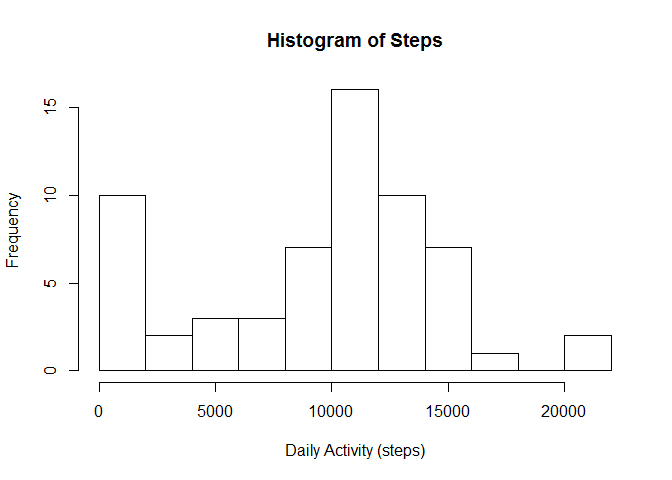

```r
#This is a rather backasswards way of listing the days on the barplot x-axis.  As always fault lays with R for it's failings.
hist(tot_stp_day$x,xlab = "Daily Activity (steps)",ylab = "Frequency",
     main = "Histogram of Steps",breaks = 10)
```

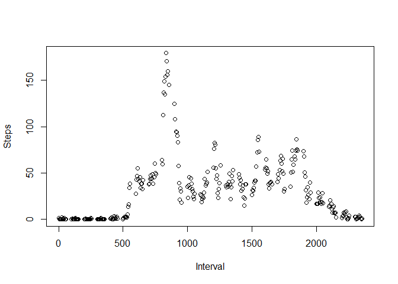

```r
plot(avg_stp_int$interval,avg_stp_int$x,xlab = 'Interval',ylab = 'Steps')
```

### Analysis: Differences between weekdays and weekends

Finally we look at our new dataset to see if there is any correlation between activity and day of the week. We’re supposed to do a panel plot, but I’ve chosen to also represent the data overlaid, as that’s how you would actually note any differences.

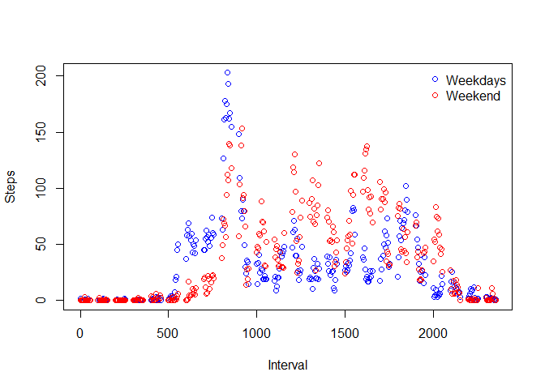

```r
days <- weekdays(as.Date(d$date))
weekend_filter = ((days=='Saturday') | (days=='Sunday'))
days[weekend_filter] = 'Weekend'
days[!weekend_filter] = 'Weekday'
d$weekday = factor(days)

avg_stp_wk_int = aggregate(d$steps, by = list(d$interval,d$weekday), mean)
colnames(avg_stp_wk_int) = c('interval','weekday','steps')
plot(avg_stp_wk_int$interval[avg_stp_wk_int$weekday == 'Weekday'],
     avg_stp_wk_int$steps[avg_stp_wk_int$weekday == 'Weekday'],col  ='blue',
     xlab = 'Interval',ylab = 'Steps')
points(avg_stp_wk_int$interval[avg_stp_wk_int$weekday == 'Weekend'],
     avg_stp_wk_int$steps[avg_stp_wk_int$weekday == 'Weekend'],col  ='red')
legend("topright", bty="n", pch = 1,col=c( "blue",'red'),
       legend=c("Weekdays", "Weekend"))
```

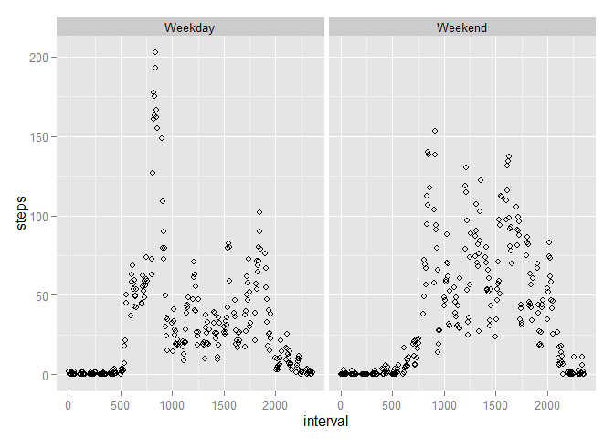

```r
sp <- ggplot(avg_stp_wk_int, aes(x=interval, y=steps)) + geom_point(shape=1)
sp + facet_grid(. ~ weekday)
```

As we would expect, the person wearing the monitor is inactive until later in the morning on the weekends, but is active until later at night. (S)He is much busier, much earlier on the weekdays, but seems to have a higher sustained activity level on the weekends.